# Risk Factor Analysis

## Outcome Variable

**Outcome Variable:** ever_wasted

## Predictor Variables

**Intervention Variable:** feducyrs

**Adjustment Set:**

unadjusted

## Stratifying Variables

The analysis was stratified on these variable(s):

- agecat
- studyid
- country

## Data Summary

| agecat | studyid | country | feducyrs | ever_wasted | n_cell | n |
| --- | --- | --- | --- | --- | --- | --- |
| 0-24 months | ki0047075b-MAL-ED | BANGLADESH | Low | 0 | 23 | 147 |
| 0-24 months | ki0047075b-MAL-ED | BANGLADESH | Low | 1 | 16 | 147 |
| 0-24 months | ki0047075b-MAL-ED | BANGLADESH | Medium | 0 | 36 | 147 |
| 0-24 months | ki0047075b-MAL-ED | BANGLADESH | Medium | 1 | 18 | 147 |
| 0-24 months | ki0047075b-MAL-ED | BANGLADESH | High | 0 | 41 | 147 |
| 0-24 months | ki0047075b-MAL-ED | BANGLADESH | High | 1 | 13 | 147 |
| 0-24 months | ki0047075b-MAL-ED | INDIA | Low | 0 | 28 | 147 |
| 0-24 months | ki0047075b-MAL-ED | INDIA | Low | 1 | 31 | 147 |
| 0-24 months | ki0047075b-MAL-ED | INDIA | Medium | 0 | 27 | 147 |
| 0-24 months | ki0047075b-MAL-ED | INDIA | Medium | 1 | 17 | 147 |
| 0-24 months | ki0047075b-MAL-ED | INDIA | High | 0 | 22 | 147 |
| 0-24 months | ki0047075b-MAL-ED | INDIA | High | 1 | 22 | 147 |
| 0-24 months | ki0047075b-MAL-ED | NEPAL | Low | 0 | 18 | 98 |
| 0-24 months | ki0047075b-MAL-ED | NEPAL | Low | 1 | 10 | 98 |
| 0-24 months | ki0047075b-MAL-ED | NEPAL | Medium | 0 | 19 | 98 |
| 0-24 months | ki0047075b-MAL-ED | NEPAL | Medium | 1 | 9 | 98 |
| 0-24 months | ki0047075b-MAL-ED | NEPAL | High | 0 | 32 | 98 |
| 0-24 months | ki0047075b-MAL-ED | NEPAL | High | 1 | 10 | 98 |
| 0-24 months | ki0047075b-MAL-ED | PERU | Low | 0 | 65 | 250 |
| 0-24 months | ki0047075b-MAL-ED | PERU | Low | 1 | 4 | 250 |
| 0-24 months | ki0047075b-MAL-ED | PERU | Medium | 0 | 54 | 250 |
| 0-24 months | ki0047075b-MAL-ED | PERU | Medium | 1 | 7 | 250 |
| 0-24 months | ki0047075b-MAL-ED | PERU | High | 0 | 112 | 250 |
| 0-24 months | ki0047075b-MAL-ED | PERU | High | 1 | 8 | 250 |
| 0-24 months | ki0047075b-MAL-ED | SOUTH AFRICA | Low | 0 | 30 | 110 |
| 0-24 months | ki0047075b-MAL-ED | SOUTH AFRICA | Low | 1 | 7 | 110 |
| 0-24 months | ki0047075b-MAL-ED | SOUTH AFRICA | Medium | 0 | 23 | 110 |
| 0-24 months | ki0047075b-MAL-ED | SOUTH AFRICA | Medium | 1 | 7 | 110 |
| 0-24 months | ki0047075b-MAL-ED | SOUTH AFRICA | High | 0 | 36 | 110 |
| 0-24 months | ki0047075b-MAL-ED | SOUTH AFRICA | High | 1 | 7 | 110 |

[output cut: 330 more lines]

The following strata were considered:

- agecat: 0-24 months, studyid: ki0047075b-MAL-ED, country: BANGLADESH
- agecat: 0-24 months, studyid: ki0047075b-MAL-ED, country: INDIA
- agecat: 0-24 months, studyid: ki0047075b-MAL-ED, country: NEPAL
- agecat: 0-24 months, studyid: ki0047075b-MAL-ED, country: PERU
- agecat: 0-24 months, studyid: ki0047075b-MAL-ED, country: SOUTH AFRICA
- agecat: 0-24 months, studyid: ki0047075b-MAL-ED, country: TANZANIA, UNITED REPUBLIC OF
- agecat: 0-24 months, studyid: ki1000304b-SAS-CompFeed, country: INDIA
- agecat: 0-24 months, studyid: ki1000304b-SAS-FoodSuppl, country: INDIA
- agecat: 0-24 months, studyid: ki1017093b-PROVIDE, country: BANGLADESH
- agecat: 0-24 months, studyid: ki1017093c-NIH-Crypto, country: BANGLADESH
- agecat: 0-24 months, studyid: ki1066203-TanzaniaChild2, country: TANZANIA, UNITED REPUBLIC OF
- agecat: 0-24 months, studyid: ki1113344-GMS-Nepal, country: NEPAL
- agecat: 0-24 months, studyid: ki1119695-PROBIT, country: BELARUS
- agecat: 0-24 months, studyid: ki1126311-ZVITAMBO, country: ZIMBABWE
- agecat: 0-24 months, studyid: ki1135781-COHORTS, country: GUATEMALA
- agecat: 0-24 months, studyid: ki1135781-COHORTS, country: INDIA
- agecat: 0-24 months, studyid: ki1135781-COHORTS, country: PHILIPPINES
- agecat: 0-24 months, studyid: ki1148112-LCNI-5, country: MALAWI
- agecat: 0-24 months, studyid: kiGH5241-JiVitA-3, country: BANGLADESH
- agecat: 0-24 months, studyid: kiGH5241-JiVitA-4, country: BANGLADESH
- agecat: 0-6 months, studyid: ki0047075b-MAL-ED, country: BANGLADESH
- agecat: 0-6 months, studyid: ki0047075b-MAL-ED, country: INDIA
- agecat: 0-6 months, studyid: ki0047075b-MAL-ED, country: NEPAL
- agecat: 0-6 months, studyid: ki0047075b-MAL-ED, country: PERU
- agecat: 0-6 months, studyid: ki0047075b-MAL-ED, country: SOUTH AFRICA
- agecat: 0-6 months, studyid: ki0047075b-MAL-ED, country: TANZANIA, UNITED REPUBLIC OF
- agecat: 0-6 months, studyid: ki1000304b-SAS-CompFeed, country: INDIA
- agecat: 0-6 months, studyid: ki1000304b-SAS-FoodSuppl, country: INDIA
- agecat: 0-6 months, studyid: ki1017093b-PROVIDE, country: BANGLADESH
- agecat: 0-6 months, studyid: ki1017093c-NIH-Crypto, country: BANGLADESH
- agecat: 0-6 months, studyid: ki1066203-TanzaniaChild2, country: TANZANIA, UNITED REPUBLIC OF
- agecat: 0-6 months, studyid: ki1113344-GMS-Nepal, country: NEPAL
- agecat: 0-6 months, studyid: ki1119695-PROBIT, country: BELARUS
- agecat: 0-6 months, studyid: ki1126311-ZVITAMBO, country: ZIMBABWE
- agecat: 0-6 months, studyid: ki1135781-COHORTS, country: GUATEMALA
- agecat: 0-6 months, studyid: ki1135781-COHORTS, country: INDIA
- agecat: 0-6 months, studyid: ki1135781-COHORTS, country: PHILIPPINES
- agecat: 0-6 months, studyid: ki1148112-LCNI-5, country: MALAWI
- agecat: 0-6 months, studyid: kiGH5241-JiVitA-3, country: BANGLADESH
- agecat: 0-6 months, studyid: kiGH5241-JiVitA-4, country: BANGLADESH
- agecat: 6-24 months, studyid: ki0047075b-MAL-ED, country: BANGLADESH
- agecat: 6-24 months, studyid: ki0047075b-MAL-ED, country: INDIA
- agecat: 6-24 months, studyid: ki0047075b-MAL-ED, country: NEPAL
- agecat: 6-24 months, studyid: ki0047075b-MAL-ED, country: PERU
- agecat: 6-24 months, studyid: ki0047075b-MAL-ED, country: SOUTH AFRICA
- agecat: 6-24 months, studyid: ki0047075b-MAL-ED, country: TANZANIA, UNITED REPUBLIC OF
- agecat: 6-24 months, studyid: ki1000304b-SAS-CompFeed, country: INDIA
- agecat: 6-24 months, studyid: ki1000304b-SAS-FoodSuppl, country: INDIA
- agecat: 6-24 months, studyid: ki1017093b-PROVIDE, country: BANGLADESH
- agecat: 6-24 months, studyid: ki1017093c-NIH-Crypto, country: BANGLADESH
- agecat: 6-24 months, studyid: ki1066203-TanzaniaChild2, country: TANZANIA, UNITED REPUBLIC OF
- agecat: 6-24 months, studyid: ki1113344-GMS-Nepal, country: NEPAL
- agecat: 6-24 months, studyid: ki1119695-PROBIT, country: BELARUS
- agecat: 6-24 months, studyid: ki1126311-ZVITAMBO, country: ZIMBABWE
- agecat: 6-24 months, studyid: ki1135781-COHORTS, country: GUATEMALA
- agecat: 6-24 months, studyid: ki1135781-COHORTS, country: INDIA
- agecat: 6-24 months, studyid: ki1135781-COHORTS, country: PHILIPPINES
- agecat: 6-24 months, studyid: ki1148112-LCNI-5, country: MALAWI
- agecat: 6-24 months, studyid: kiGH5241-JiVitA-3, country: BANGLADESH
- agecat: 6-24 months, studyid: kiGH5241-JiVitA-4, country: BANGLADESH

### Dropped Strata

Some strata were dropped due to rare outcomes:

- agecat: 0-24 months, studyid: ki0047075b-MAL-ED, country: PERU
- agecat: 0-24 months, studyid: ki0047075b-MAL-ED, country: TANZANIA, UNITED REPUBLIC OF
- agecat: 0-6 months, studyid: ki0047075b-MAL-ED, country: NEPAL
- agecat: 0-6 months, studyid: ki0047075b-MAL-ED, country: PERU
- agecat: 0-6 months, studyid: ki0047075b-MAL-ED, country: SOUTH AFRICA
- agecat: 0-6 months, studyid: ki0047075b-MAL-ED, country: TANZANIA, UNITED REPUBLIC OF
- agecat: 0-6 months, studyid: ki1148112-LCNI-5, country: MALAWI
- agecat: 6-24 months, studyid: ki0047075b-MAL-ED, country: NEPAL
- agecat: 6-24 months, studyid: ki0047075b-MAL-ED, country: PERU
- agecat: 6-24 months, studyid: ki0047075b-MAL-ED, country: SOUTH AFRICA
- agecat: 6-24 months, studyid: ki0047075b-MAL-ED, country: TANZANIA, UNITED REPUBLIC OF

## Methods Detail

We’re interested in the causal parameters $E[Y_a]$ for all values of $a \in \mathcal{A}$. These parameters represent the mean outcome if, possibly contrary to fact, we intervened to set all units to have $A=a$. Under the randomization and positivity assumptions, these are identified by the statistical parameters $\psi_a=E_W[E_{Y|A,W}(Y|A=a,W)]$. In addition, we’re interested in the mean of $Y$, $E[Y]$ under no intervention (the observed mean). We will estimate these parameters by using SuperLearner to fit the relevant likelihood factors – $E_{Y|A,W}(Y|A=a,W)$ and $p(A=a|W)$, and then updating our likelihood fit using a joint TMLE.

For unadjusted analyses ($W=\{\}$), initial likelihoods were estimated using Lrnr_glm to estimate the simple $E(Y|A)$ and Lrnr_mean to estimate $p(A)$. For adjusted analyses, a small library containing Lrnr_glmnet, Lrnr_xgboost, and Lrnr_mean was used.

Having estimated these parameters, we will then use the delta method to estimate relative risks and attributable risks relative to a prespecified baseline level of $A$.

# Results Detail

## Results Plots

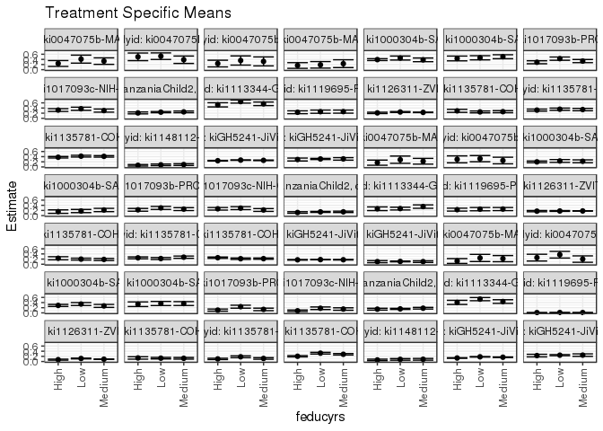

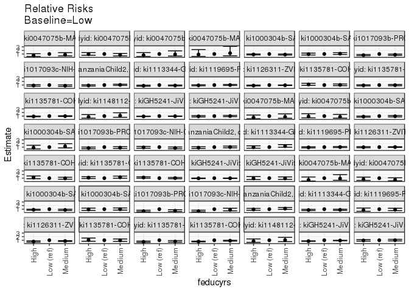

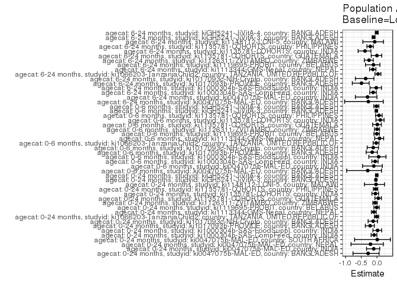

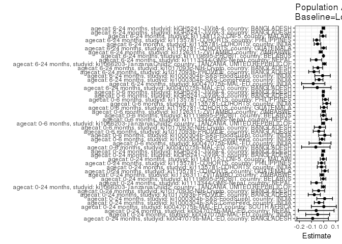

## Results Table

### Parameter: TSM

| agecat | studyid | country | intervention_level | baseline_level | estimate | ci_lower | ci_upper |
| --- | --- | --- | --- | --- | --- | --- | --- |
| 0-24 months | ki0047075b-MAL-ED | BANGLADESH | Low | NA | 0.4102564 | 0.2553543 | 0.5651585 |
| 0-24 months | ki0047075b-MAL-ED | BANGLADESH | Medium | NA | 0.3333333 | 0.2071717 | 0.4594949 |
| 0-24 months | ki0047075b-MAL-ED | BANGLADESH | High | NA | 0.2407407 | 0.1263204 | 0.3551611 |
| 0-24 months | ki0047075b-MAL-ED | INDIA | Low | NA | 0.5254237 | 0.3975704 | 0.6532771 |
| 0-24 months | ki0047075b-MAL-ED | INDIA | Medium | NA | 0.3863636 | 0.2420001 | 0.5307272 |
| 0-24 months | ki0047075b-MAL-ED | INDIA | High | NA | 0.5000000 | 0.3517571 | 0.6482429 |
| 0-24 months | ki0047075b-MAL-ED | NEPAL | Low | NA | 0.3571429 | 0.1787512 | 0.5355345 |
| 0-24 months | ki0047075b-MAL-ED | NEPAL | Medium | NA | 0.3214286 | 0.1475539 | 0.4953032 |
| 0-24 months | ki0047075b-MAL-ED | NEPAL | High | NA | 0.2380952 | 0.1086231 | 0.3675674 |
| 0-24 months | ki0047075b-MAL-ED | SOUTH AFRICA | Low | NA | 0.1891892 | 0.0624128 | 0.3159655 |
| 0-24 months | ki0047075b-MAL-ED | SOUTH AFRICA | Medium | NA | 0.2333333 | 0.0812918 | 0.3853749 |
| 0-24 months | ki0047075b-MAL-ED | SOUTH AFRICA | High | NA | 0.1627907 | 0.0519425 | 0.2736389 |
| 0-24 months | ki1000304b-SAS-CompFeed | INDIA | Low | NA | 0.4525661 | 0.3744447 | 0.5306875 |
| 0-24 months | ki1000304b-SAS-CompFeed | INDIA | Medium | NA | 0.3825364 | 0.3114525 | 0.4536203 |
| 0-24 months | ki1000304b-SAS-CompFeed | INDIA | High | NA | 0.3911917 | 0.3550083 | 0.4273751 |
| 0-24 months | ki1000304b-SAS-FoodSuppl | INDIA | Low | NA | 0.4625850 | 0.3818875 | 0.5432826 |
| 0-24 months | ki1000304b-SAS-FoodSuppl | INDIA | Medium | NA | 0.5031056 | 0.4257811 | 0.5804300 |
| 0-24 months | ki1000304b-SAS-FoodSuppl | INDIA | High | NA | 0.4363636 | 0.3435748 | 0.5291525 |
| 0-24 months | ki1017093b-PROVIDE | BANGLADESH | Low | NA | 0.4285714 | 0.3656552 | 0.4914876 |
| 0-24 months | ki1017093b-PROVIDE | BANGLADESH | Medium | NA | 0.3347826 | 0.2737506 | 0.3958146 |
| 0-24 months | ki1017093b-PROVIDE | BANGLADESH | High | NA | 0.2887931 | 0.2304344 | 0.3471518 |
| 0-24 months | ki1017093c-NIH-Crypto | BANGLADESH | Low | NA | 0.3719008 | 0.3109675 | 0.4328341 |
| 0-24 months | ki1017093c-NIH-Crypto | BANGLADESH | Medium | NA | 0.3000000 | 0.2394055 | 0.3605945 |
| 0-24 months | ki1017093c-NIH-Crypto | BANGLADESH | High | NA | 0.3209459 | 0.2677281 | 0.3741638 |
| 0-24 months | ki1066203-TanzaniaChild2 | TANZANIA, UNITED REPUBLIC OF | Low | NA | 0.2393701 | 0.2158976 | 0.2628426 |
| 0-24 months | ki1066203-TanzaniaChild2 | TANZANIA, UNITED REPUBLIC OF | Medium | NA | 0.2500000 | 0.2170576 | 0.2829424 |
| 0-24 months | ki1066203-TanzaniaChild2 | TANZANIA, UNITED REPUBLIC OF | High | NA | 0.2093541 | 0.1717143 | 0.2469940 |
| 0-24 months | ki1113344-GMS-Nepal | NEPAL | Low | NA | 0.6498054 | 0.5914355 | 0.7081754 |
| 0-24 months | ki1113344-GMS-Nepal | NEPAL | Medium | NA | 0.5634518 | 0.4941378 | 0.6327658 |
| 0-24 months | ki1113344-GMS-Nepal | NEPAL | High | NA | 0.5238095 | 0.4430064 | 0.6046126 |

[output cut: 117 more lines]

### Parameter: E(Y)

| agecat | studyid | country | intervention_level | baseline_level | estimate | ci_lower | ci_upper |
| --- | --- | --- | --- | --- | --- | --- | --- |
| 0-24 months | ki0047075b-MAL-ED | BANGLADESH | NA | NA | 0.3197279 | 0.2440789 | 0.3953769 |
| 0-24 months | ki0047075b-MAL-ED | INDIA | NA | NA | 0.4761905 | 0.3951786 | 0.5572024 |
| 0-24 months | ki0047075b-MAL-ED | NEPAL | NA | NA | 0.2959184 | 0.2050820 | 0.3867547 |
| 0-24 months | ki0047075b-MAL-ED | SOUTH AFRICA | NA | NA | 0.1909091 | 0.1171277 | 0.2646905 |
| 0-24 months | ki1000304b-SAS-CompFeed | INDIA | NA | NA | 0.4145695 | 0.3576236 | 0.4715155 |
| 0-24 months | ki1000304b-SAS-FoodSuppl | INDIA | NA | NA | 0.4712919 | 0.4233811 | 0.5192026 |
| 0-24 months | ki1017093b-PROVIDE | BANGLADESH | NA | NA | 0.3514286 | 0.3160364 | 0.3868207 |
| 0-24 months | ki1017093c-NIH-Crypto | BANGLADESH | NA | NA | 0.3311346 | 0.2976093 | 0.3646598 |
| 0-24 months | ki1066203-TanzaniaChild2 | TANZANIA, UNITED REPUBLIC OF | NA | NA | 0.2366765 | 0.2196074 | 0.2537455 |
| 0-24 months | ki1113344-GMS-Nepal | NEPAL | NA | NA | 0.5906822 | 0.5513381 | 0.6300263 |
| 0-24 months | ki1119695-PROBIT | BELARUS | NA | NA | 0.2556543 | 0.1980936 | 0.3132150 |
| 0-24 months | ki1126311-ZVITAMBO | ZIMBABWE | NA | NA | 0.2317505 | 0.2246488 | 0.2388522 |
| 0-24 months | ki1135781-COHORTS | GUATEMALA | NA | NA | 0.2601297 | 0.2356425 | 0.2846169 |
| 0-24 months | ki1135781-COHORTS | INDIA | NA | NA | 0.3365584 | 0.3122030 | 0.3609138 |
| 0-24 months | ki1135781-COHORTS | PHILIPPINES | NA | NA | 0.4013250 | 0.3833827 | 0.4192673 |
| 0-24 months | ki1148112-LCNI-5 | MALAWI | NA | NA | 0.0799508 | 0.0612962 | 0.0986054 |
| 0-24 months | kiGH5241-JiVitA-3 | BANGLADESH | NA | NA | 0.2575635 | 0.2509808 | 0.2641462 |
| 0-24 months | kiGH5241-JiVitA-4 | BANGLADESH | NA | NA | 0.3085018 | 0.2890487 | 0.3279548 |
| 0-6 months | ki0047075b-MAL-ED | BANGLADESH | NA | NA | 0.2176871 | 0.1507482 | 0.2846259 |
| 0-6 months | ki0047075b-MAL-ED | INDIA | NA | NA | 0.2925170 | 0.2187257 | 0.3663083 |
| 0-6 months | ki1000304b-SAS-CompFeed | INDIA | NA | NA | 0.2197071 | 0.1750081 | 0.2644060 |
| 0-6 months | ki1000304b-SAS-FoodSuppl | INDIA | NA | NA | 0.1866029 | 0.1492099 | 0.2239959 |
| 0-6 months | ki1017093b-PROVIDE | BANGLADESH | NA | NA | 0.2585714 | 0.2261125 | 0.2910304 |
| 0-6 months | ki1017093c-NIH-Crypto | BANGLADESH | NA | NA | 0.2585752 | 0.2273844 | 0.2897660 |
| 0-6 months | ki1066203-TanzaniaChild2 | TANZANIA, UNITED REPUBLIC OF | NA | NA | 0.1397398 | 0.1258162 | 0.1536634 |
| 0-6 months | ki1113344-GMS-Nepal | NEPAL | NA | NA | 0.2961730 | 0.2596406 | 0.3327054 |
| 0-6 months | ki1119695-PROBIT | BELARUS | NA | NA | 0.2487739 | 0.1904535 | 0.3070943 |
| 0-6 months | ki1126311-ZVITAMBO | ZIMBABWE | NA | NA | 0.1794091 | 0.1729298 | 0.1858885 |
| 0-6 months | ki1135781-COHORTS | GUATEMALA | NA | NA | 0.2006018 | 0.1757323 | 0.2254713 |
| 0-6 months | ki1135781-COHORTS | INDIA | NA | NA | 0.2462950 | 0.2238538 | 0.2687361 |
| 0-6 months | ki1135781-COHORTS | PHILIPPINES | NA | NA | 0.2291594 | 0.2137721 | 0.2445467 |
| 0-6 months | kiGH5241-JiVitA-3 | BANGLADESH | NA | NA | 0.1758866 | 0.1701478 | 0.1816254 |
| 0-6 months | kiGH5241-JiVitA-4 | BANGLADESH | NA | NA | 0.1055729 | 0.0925062 | 0.1186395 |
| 6-24 months | ki0047075b-MAL-ED | BANGLADESH | NA | NA | 0.1908397 | 0.1232893 | 0.2583901 |
| 6-24 months | ki0047075b-MAL-ED | INDIA | NA | NA | 0.2846715 | 0.2088306 | 0.3605124 |
| 6-24 months | ki1000304b-SAS-CompFeed | INDIA | NA | NA | 0.3051948 | 0.2633957 | 0.3469939 |
| 6-24 months | ki1000304b-SAS-FoodSuppl | INDIA | NA | NA | 0.3557214 | 0.3088651 | 0.4025777 |
| 6-24 months | ki1017093b-PROVIDE | BANGLADESH | NA | NA | 0.1609756 | 0.1319065 | 0.1900447 |
| 6-24 months | ki1017093c-NIH-Crypto | BANGLADESH | NA | NA | 0.1315068 | 0.1069744 | 0.1560393 |
| 6-24 months | ki1066203-TanzaniaChild2 | TANZANIA, UNITED REPUBLIC OF | NA | NA | 0.1602787 | 0.1442326 | 0.1763249 |
| 6-24 months | ki1113344-GMS-Nepal | NEPAL | NA | NA | 0.4719864 | 0.4316361 | 0.5123367 |
| 6-24 months | ki1119695-PROBIT | BELARUS | NA | NA | 0.0102327 | 0.0075781 | 0.0128874 |
| 6-24 months | ki1126311-ZVITAMBO | ZIMBABWE | NA | NA | 0.0926247 | 0.0870490 | 0.0982004 |
| 6-24 months | ki1135781-COHORTS | GUATEMALA | NA | NA | 0.1288889 | 0.1093000 | 0.1484778 |
| 6-24 months | ki1135781-COHORTS | INDIA | NA | NA | 0.1323843 | 0.1146569 | 0.1501118 |
| 6-24 months | ki1135781-COHORTS | PHILIPPINES | NA | NA | 0.2666667 | 0.2498425 | 0.2834908 |
| 6-24 months | ki1148112-LCNI-5 | MALAWI | NA | NA | 0.0773067 | 0.0588111 | 0.0958024 |
| 6-24 months | kiGH5241-JiVitA-3 | BANGLADESH | NA | NA | 0.1644249 | 0.1581893 | 0.1706604 |
| 6-24 months | kiGH5241-JiVitA-4 | BANGLADESH | NA | NA | 0.2442659 | 0.2256986 | 0.2628332 |

### Parameter: RR

| agecat | studyid | country | intervention_level | baseline_level | estimate | ci_lower | ci_upper |
| --- | --- | --- | --- | --- | --- | --- | --- |
| 0-24 months | ki0047075b-MAL-ED | BANGLADESH | Low | Low | 1.0000000 | 1.0000000 | 1.0000000 |
| 0-24 months | ki0047075b-MAL-ED | BANGLADESH | Medium | Low | 0.8125000 | 0.4760397 | 1.3867672 |
| 0-24 months | ki0047075b-MAL-ED | BANGLADESH | High | Low | 0.5868056 | 0.3197970 | 1.0767478 |
| 0-24 months | ki0047075b-MAL-ED | INDIA | Low | Low | 1.0000000 | 1.0000000 | 1.0000000 |
| 0-24 months | ki0047075b-MAL-ED | INDIA | Medium | Low | 0.7353372 | 0.4707999 | 1.1485153 |
| 0-24 months | ki0047075b-MAL-ED | INDIA | High | Low | 0.9516129 | 0.6484613 | 1.3964860 |
| 0-24 months | ki0047075b-MAL-ED | NEPAL | Low | Low | 1.0000000 | 1.0000000 | 1.0000000 |
| 0-24 months | ki0047075b-MAL-ED | NEPAL | Medium | Low | 0.9000000 | 0.4310005 | 1.8793484 |
| 0-24 months | ki0047075b-MAL-ED | NEPAL | High | Low | 0.6666667 | 0.3185934 | 1.3950207 |
| 0-24 months | ki0047075b-MAL-ED | SOUTH AFRICA | Low | Low | 1.0000000 | 1.0000000 | 1.0000000 |
| 0-24 months | ki0047075b-MAL-ED | SOUTH AFRICA | Medium | Low | 1.2333333 | 0.4843434 | 3.1405635 |
| 0-24 months | ki0047075b-MAL-ED | SOUTH AFRICA | High | Low | 0.8604651 | 0.3310009 | 2.2368526 |
| 0-24 months | ki1000304b-SAS-CompFeed | INDIA | Low | Low | 1.0000000 | 1.0000000 | 1.0000000 |
| 0-24 months | ki1000304b-SAS-CompFeed | INDIA | Medium | Low | 0.8452608 | 0.7080170 | 1.0091083 |
| 0-24 months | ki1000304b-SAS-CompFeed | INDIA | High | Low | 0.8643858 | 0.7358744 | 1.0153401 |
| 0-24 months | ki1000304b-SAS-FoodSuppl | INDIA | Low | Low | 1.0000000 | 1.0000000 | 1.0000000 |
| 0-24 months | ki1000304b-SAS-FoodSuppl | INDIA | Medium | Low | 1.0875959 | 0.8619773 | 1.3722692 |
| 0-24 months | ki1000304b-SAS-FoodSuppl | INDIA | High | Low | 0.9433155 | 0.7164853 | 1.2419573 |
| 0-24 months | ki1017093b-PROVIDE | BANGLADESH | Low | Low | 1.0000000 | 1.0000000 | 1.0000000 |
| 0-24 months | ki1017093b-PROVIDE | BANGLADESH | Medium | Low | 0.7811594 | 0.6181400 | 0.9871713 |
| 0-24 months | ki1017093b-PROVIDE | BANGLADESH | High | Low | 0.6738506 | 0.5249139 | 0.8650458 |
| 0-24 months | ki1017093c-NIH-Crypto | BANGLADESH | Low | Low | 1.0000000 | 1.0000000 | 1.0000000 |
| 0-24 months | ki1017093c-NIH-Crypto | BANGLADESH | Medium | Low | 0.8066667 | 0.6219325 | 1.0462729 |
| 0-24 months | ki1017093c-NIH-Crypto | BANGLADESH | High | Low | 0.8629880 | 0.6835453 | 1.0895376 |
| 0-24 months | ki1066203-TanzaniaChild2 | TANZANIA, UNITED REPUBLIC OF | Low | Low | 1.0000000 | 1.0000000 | 1.0000000 |
| 0-24 months | ki1066203-TanzaniaChild2 | TANZANIA, UNITED REPUBLIC OF | Medium | Low | 1.0444079 | 0.8862090 | 1.2308472 |
| 0-24 months | ki1066203-TanzaniaChild2 | TANZANIA, UNITED REPUBLIC OF | High | Low | 0.8746044 | 0.7126416 | 1.0733767 |
| 0-24 months | ki1113344-GMS-Nepal | NEPAL | Low | Low | 1.0000000 | 1.0000000 | 1.0000000 |
| 0-24 months | ki1113344-GMS-Nepal | NEPAL | Medium | Low | 0.8671084 | 0.7445962 | 1.0097782 |
| 0-24 months | ki1113344-GMS-Nepal | NEPAL | High | Low | 0.8061021 | 0.6743183 | 0.9636407 |

[output cut: 117 more lines]

### Parameter: PAR

| agecat | studyid | country | intervention_level | baseline_level | estimate | ci_lower | ci_upper |
| --- | --- | --- | --- | --- | --- | --- | --- |
| 0-24 months | ki0047075b-MAL-ED | BANGLADESH | Low | NA | -0.0905285 | -0.2208572 | 0.0398002 |
| 0-24 months | ki0047075b-MAL-ED | INDIA | Low | NA | -0.0492333 | -0.1481663 | 0.0496998 |
| 0-24 months | ki0047075b-MAL-ED | NEPAL | Low | NA | -0.0612245 | -0.2091769 | 0.0867279 |
| 0-24 months | ki0047075b-MAL-ED | SOUTH AFRICA | Low | NA | 0.0017199 | -0.1017388 | 0.1051786 |
| 0-24 months | ki1000304b-SAS-CompFeed | INDIA | Low | NA | -0.0379966 | -0.0769426 | 0.0009495 |
| 0-24 months | ki1000304b-SAS-FoodSuppl | INDIA | Low | NA | 0.0087068 | -0.0563105 | 0.0737242 |
| 0-24 months | ki1017093b-PROVIDE | BANGLADESH | Low | NA | -0.0771429 | -0.1273356 | -0.0269501 |
| 0-24 months | ki1017093c-NIH-Crypto | BANGLADESH | Low | NA | -0.0407663 | -0.0904257 | 0.0088932 |
| 0-24 months | ki1066203-TanzaniaChild2 | TANZANIA, UNITED REPUBLIC OF | Low | NA | -0.0026936 | -0.0186640 | 0.0132768 |
| 0-24 months | ki1113344-GMS-Nepal | NEPAL | Low | NA | -0.0591233 | -0.1043024 | -0.0139441 |
| 0-24 months | ki1119695-PROBIT | BELARUS | Low | NA | -0.0026816 | -0.0241101 | 0.0187469 |
| 0-24 months | ki1126311-ZVITAMBO | ZIMBABWE | Low | NA | -0.0139788 | -0.0300201 | 0.0020624 |
| 0-24 months | ki1135781-COHORTS | GUATEMALA | Low | NA | 0.0110257 | -0.0158603 | 0.0379118 |
| 0-24 months | ki1135781-COHORTS | INDIA | Low | NA | -0.0172552 | -0.0524753 | 0.0179650 |
| 0-24 months | ki1135781-COHORTS | PHILIPPINES | Low | NA | -0.0175612 | -0.0458822 | 0.0107598 |
| 0-24 months | ki1148112-LCNI-5 | MALAWI | Low | NA | -0.0025234 | -0.0276666 | 0.0226197 |
| 0-24 months | kiGH5241-JiVitA-3 | BANGLADESH | Low | NA | -0.0091784 | -0.0161291 | -0.0022277 |
| 0-24 months | kiGH5241-JiVitA-4 | BANGLADESH | Low | NA | -0.0024052 | -0.0143702 | 0.0095597 |
| 0-6 months | ki0047075b-MAL-ED | BANGLADESH | Low | NA | -0.0643642 | -0.1822934 | 0.0535649 |
| 0-6 months | ki0047075b-MAL-ED | INDIA | Low | NA | -0.0295169 | -0.1204494 | 0.0614157 |
| 0-6 months | ki1000304b-SAS-CompFeed | INDIA | Low | NA | -0.0131054 | -0.0353468 | 0.0091359 |
| 0-6 months | ki1000304b-SAS-FoodSuppl | INDIA | Low | NA | 0.0097321 | -0.0405627 | 0.0600269 |
| 0-6 months | ki1017093b-PROVIDE | BANGLADESH | Low | NA | -0.0397479 | -0.0859679 | 0.0064721 |
| 0-6 months | ki1017093c-NIH-Crypto | BANGLADESH | Low | NA | -0.0306810 | -0.0770932 | 0.0157312 |
| 0-6 months | ki1066203-TanzaniaChild2 | TANZANIA, UNITED REPUBLIC OF | Low | NA | -0.0035673 | -0.0165823 | 0.0094478 |
| 0-6 months | ki1113344-GMS-Nepal | NEPAL | Low | NA | 0.0237995 | -0.0182024 | 0.0658014 |
| 0-6 months | ki1119695-PROBIT | BELARUS | Low | NA | -0.0017714 | -0.0233023 | 0.0197594 |
| 0-6 months | ki1126311-ZVITAMBO | ZIMBABWE | Low | NA | 0.0008377 | -0.0135425 | 0.0152179 |
| 0-6 months | ki1135781-COHORTS | GUATEMALA | Low | NA | 0.0019562 | -0.0258346 | 0.0297470 |
| 0-6 months | ki1135781-COHORTS | INDIA | Low | NA | 0.0257710 | -0.0060679 | 0.0576099 |
| 0-6 months | ki1135781-COHORTS | PHILIPPINES | Low | NA | 0.0148737 | -0.0089741 | 0.0387215 |
| 0-6 months | kiGH5241-JiVitA-3 | BANGLADESH | Low | NA | -0.0037457 | -0.0099627 | 0.0024713 |
| 0-6 months | kiGH5241-JiVitA-4 | BANGLADESH | Low | NA | -0.0018416 | -0.0103072 | 0.0066241 |
| 6-24 months | ki0047075b-MAL-ED | BANGLADESH | Low | NA | -0.0524035 | -0.1661693 | 0.0613622 |
| 6-24 months | ki0047075b-MAL-ED | INDIA | Low | NA | -0.0856988 | -0.1820795 | 0.0106818 |
| 6-24 months | ki1000304b-SAS-CompFeed | INDIA | Low | NA | -0.0374625 | -0.0694489 | -0.0054762 |
| 6-24 months | ki1000304b-SAS-FoodSuppl | INDIA | Low | NA | -0.0085643 | -0.0728197 | 0.0556911 |
| 6-24 months | ki1017093b-PROVIDE | BANGLADESH | Low | NA | -0.0794090 | -0.1234318 | -0.0353862 |
| 6-24 months | ki1017093c-NIH-Crypto | BANGLADESH | Low | NA | -0.0475325 | -0.0865429 | -0.0085220 |
| 6-24 months | ki1066203-TanzaniaChild2 | TANZANIA, UNITED REPUBLIC OF | Low | NA | 0.0054280 | -0.0096036 | 0.0204596 |
| 6-24 months | ki1113344-GMS-Nepal | NEPAL | Low | NA | -0.0616104 | -0.1081028 | -0.0151180 |
| 6-24 months | ki1119695-PROBIT | BELARUS | Low | NA | -0.0011579 | -0.0035954 | 0.0012797 |
| 6-24 months | ki1126311-ZVITAMBO | ZIMBABWE | Low | NA | -0.0235115 | -0.0367530 | -0.0102700 |
| 6-24 months | ki1135781-COHORTS | GUATEMALA | Low | NA | -0.0002696 | -0.0217454 | 0.0212061 |
| 6-24 months | ki1135781-COHORTS | INDIA | Low | NA | -0.0506222 | -0.0779773 | -0.0232671 |
| 6-24 months | ki1135781-COHORTS | PHILIPPINES | Low | NA | -0.0572408 | -0.0842742 | -0.0302074 |
| 6-24 months | ki1148112-LCNI-5 | MALAWI | Low | NA | -0.0057382 | -0.0307412 | 0.0192647 |
| 6-24 months | kiGH5241-JiVitA-3 | BANGLADESH | Low | NA | -0.0176315 | -0.0250432 | -0.0102199 |
| 6-24 months | kiGH5241-JiVitA-4 | BANGLADESH | Low | NA | -0.0016471 | -0.0127787 | 0.0094845 |

### Parameter: PAF

| agecat | studyid | country | intervention_level | baseline_level | estimate | ci_lower | ci_upper |
| --- | --- | --- | --- | --- | --- | --- | --- |
| 0-24 months | ki0047075b-MAL-ED | BANGLADESH | Low | NA | -0.2831424 | -0.7645074 | 0.0669042 |
| 0-24 months | ki0047075b-MAL-ED | INDIA | Low | NA | -0.1033898 | -0.3328996 | 0.0866010 |
| 0-24 months | ki0047075b-MAL-ED | NEPAL | Low | NA | -0.2068966 | -0.8264376 | 0.2024916 |
| 0-24 months | ki0047075b-MAL-ED | SOUTH AFRICA | Low | NA | 0.0090090 | -0.7122310 | 0.4264424 |
| 0-24 months | ki1000304b-SAS-CompFeed | INDIA | Low | NA | -0.0916530 | -0.1864729 | -0.0044110 |
| 0-24 months | ki1000304b-SAS-FoodSuppl | INDIA | Low | NA | 0.0184744 | -0.1296579 | 0.1471820 |
| 0-24 months | ki1017093b-PROVIDE | BANGLADESH | Low | NA | -0.2195122 | -0.3716544 | -0.0842455 |
| 0-24 months | ki1017093c-NIH-Crypto | BANGLADESH | Low | NA | -0.1231109 | -0.2836181 | 0.0173261 |
| 0-24 months | ki1066203-TanzaniaChild2 | TANZANIA, UNITED REPUBLIC OF | Low | NA | -0.0113810 | -0.0811586 | 0.0538932 |
| 0-24 months | ki1113344-GMS-Nepal | NEPAL | Low | NA | -0.1000932 | -0.1799762 | -0.0256181 |
| 0-24 months | ki1119695-PROBIT | BELARUS | Low | NA | -0.0104893 | -0.0976749 | 0.0697715 |
| 0-24 months | ki1126311-ZVITAMBO | ZIMBABWE | Low | NA | -0.0603184 | -0.1318358 | 0.0066800 |
| 0-24 months | ki1135781-COHORTS | GUATEMALA | Low | NA | 0.0423855 | -0.0667268 | 0.1403370 |
| 0-24 months | ki1135781-COHORTS | INDIA | Low | NA | -0.0512694 | -0.1613079 | 0.0483425 |
| 0-24 months | ki1135781-COHORTS | PHILIPPINES | Low | NA | -0.0437581 | -0.1167787 | 0.0244880 |
| 0-24 months | ki1148112-LCNI-5 | MALAWI | Low | NA | -0.0315623 | -0.3991519 | 0.2394531 |
| 0-24 months | kiGH5241-JiVitA-3 | BANGLADESH | Low | NA | -0.0356355 | -0.0630304 | -0.0089467 |
| 0-24 months | kiGH5241-JiVitA-4 | BANGLADESH | Low | NA | -0.0077966 | -0.0473090 | 0.0302252 |
| 0-6 months | ki0047075b-MAL-ED | BANGLADESH | Low | NA | -0.2956731 | -0.9650094 | 0.1456689 |
| 0-6 months | ki0047075b-MAL-ED | INDIA | Low | NA | -0.1009066 | -0.4599740 | 0.1698515 |
| 0-6 months | ki1000304b-SAS-CompFeed | INDIA | Low | NA | -0.0596496 | -0.1630243 | 0.0345367 |
| 0-6 months | ki1000304b-SAS-FoodSuppl | INDIA | Low | NA | 0.0521542 | -0.2594495 | 0.2866632 |
| 0-6 months | ki1017093b-PROVIDE | BANGLADESH | Low | NA | -0.1537212 | -0.3468261 | 0.0116969 |
| 0-6 months | ki1017093c-NIH-Crypto | BANGLADESH | Low | NA | -0.1186541 | -0.3132010 | 0.0470713 |
| 0-6 months | ki1066203-TanzaniaChild2 | TANZANIA, UNITED REPUBLIC OF | Low | NA | -0.0255279 | -0.1230005 | 0.0634844 |
| 0-6 months | ki1113344-GMS-Nepal | NEPAL | Low | NA | 0.0803568 | -0.0728860 | 0.2117115 |
| 0-6 months | ki1119695-PROBIT | BELARUS | Low | NA | -0.0071207 | -0.0973270 | 0.0756703 |
| 0-6 months | ki1126311-ZVITAMBO | ZIMBABWE | Low | NA | 0.0046693 | -0.0787995 | 0.0816800 |
| 0-6 months | ki1135781-COHORTS | GUATEMALA | Low | NA | 0.0097517 | -0.1389415 | 0.1390324 |
| 0-6 months | ki1135781-COHORTS | INDIA | Low | NA | 0.1046346 | -0.0342660 | 0.2248810 |
| 0-6 months | ki1135781-COHORTS | PHILIPPINES | Low | NA | 0.0649054 | -0.0451275 | 0.1633539 |
| 0-6 months | kiGH5241-JiVitA-3 | BANGLADESH | Low | NA | -0.0212959 | -0.0572975 | 0.0134797 |
| 0-6 months | kiGH5241-JiVitA-4 | BANGLADESH | Low | NA | -0.0174437 | -0.1008541 | 0.0596467 |
| 6-24 months | ki0047075b-MAL-ED | BANGLADESH | Low | NA | -0.2745946 | -1.0296154 | 0.1995570 |
| 6-24 months | ki0047075b-MAL-ED | INDIA | Low | NA | -0.3010446 | -0.6881859 | -0.0026841 |
| 6-24 months | ki1000304b-SAS-CompFeed | INDIA | Low | NA | -0.1227496 | -0.2306674 | -0.0242952 |
| 6-24 months | ki1000304b-SAS-FoodSuppl | INDIA | Low | NA | -0.0240759 | -0.2216247 | 0.1415272 |
| 6-24 months | ki1017093b-PROVIDE | BANGLADESH | Low | NA | -0.4932984 | -0.7859056 | -0.2486327 |
| 6-24 months | ki1017093c-NIH-Crypto | BANGLADESH | Low | NA | -0.3614447 | -0.6872505 | -0.0985515 |
| 6-24 months | ki1066203-TanzaniaChild2 | TANZANIA, UNITED REPUBLIC OF | Low | NA | 0.0338660 | -0.0645786 | 0.1232072 |
| 6-24 months | ki1113344-GMS-Nepal | NEPAL | Low | NA | -0.1305343 | -0.2341589 | -0.0356104 |
| 6-24 months | ki1119695-PROBIT | BELARUS | Low | NA | -0.1131536 | -0.3664734 | 0.0932052 |
| 6-24 months | ki1126311-ZVITAMBO | ZIMBABWE | Low | NA | -0.2538368 | -0.4045818 | -0.1192702 |
| 6-24 months | ki1135781-COHORTS | GUATEMALA | Low | NA | -0.0020919 | -0.1833670 | 0.1514144 |
| 6-24 months | ki1135781-COHORTS | INDIA | Low | NA | -0.3823881 | -0.6009728 | -0.1936473 |
| 6-24 months | ki1135781-COHORTS | PHILIPPINES | Low | NA | -0.2146530 | -0.3202642 | -0.1174898 |
| 6-24 months | ki1148112-LCNI-5 | MALAWI | Low | NA | -0.0742270 | -0.4510767 | 0.2047535 |
| 6-24 months | kiGH5241-JiVitA-3 | BANGLADESH | Low | NA | -0.1072316 | -0.1531010 | -0.0631869 |
| 6-24 months | kiGH5241-JiVitA-4 | BANGLADESH | Low | NA | -0.0067431 | -0.0533412 | 0.0377936 |